# Analysis of noveltyVR

# Aims

This document runs a quick analysis on the data.

# Condition

## Loading data

### Encoding task

Is there a reaction time and accuracy difference?

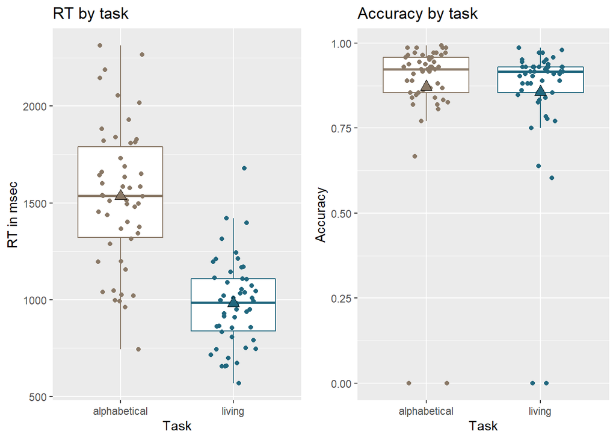

Note that for the first participant, the responses were not saved correctly and have to be inverted.

There is strong evidence that RT are faster in the living condition (BF10 = 1.074589510^{16}), however there is also evidence that accuracy does not differ between the condition (BF01 = 2.58).

### Recognition task

Are there RT difference between RFN?

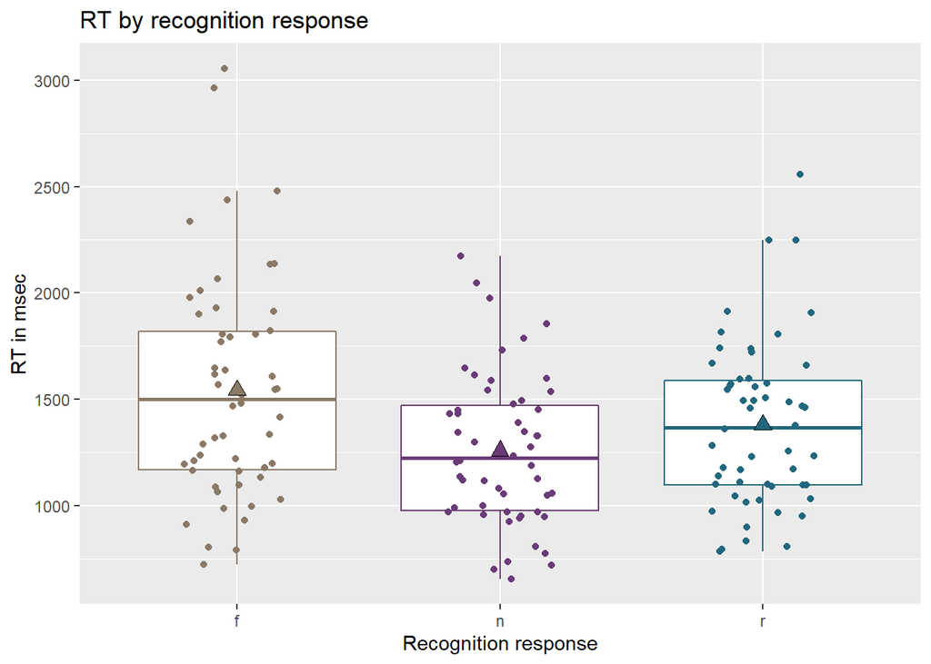

This comparison showed a main effect of recognition type (BF10 = 1.024710^{4}).

Run MTP analysis

```
## [1] "Model fitting begins at 2021-05-08 14:36:22"
## [1] "Model fitting stopped at 2021-05-08 14:36:41"
## Time difference of 19.81442 secs
```

```
## [1] "Model fitting begins at 2021-05-08 14:36:42"
## [1] "Model fitting stopped at 2021-05-08 14:37:01"
## Time difference of 18.97316 secs
```

Combining everything into one data frame

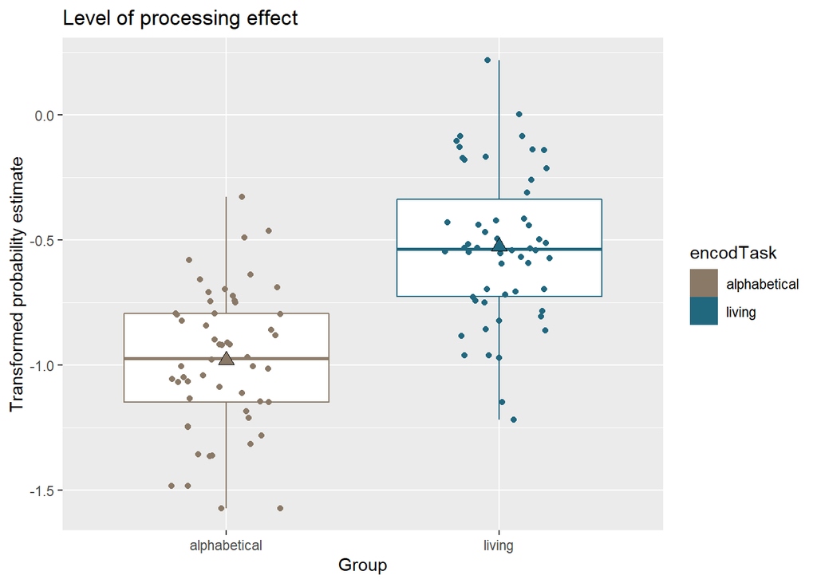

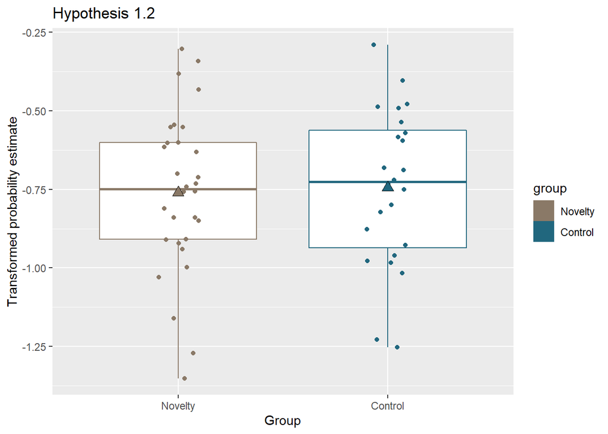

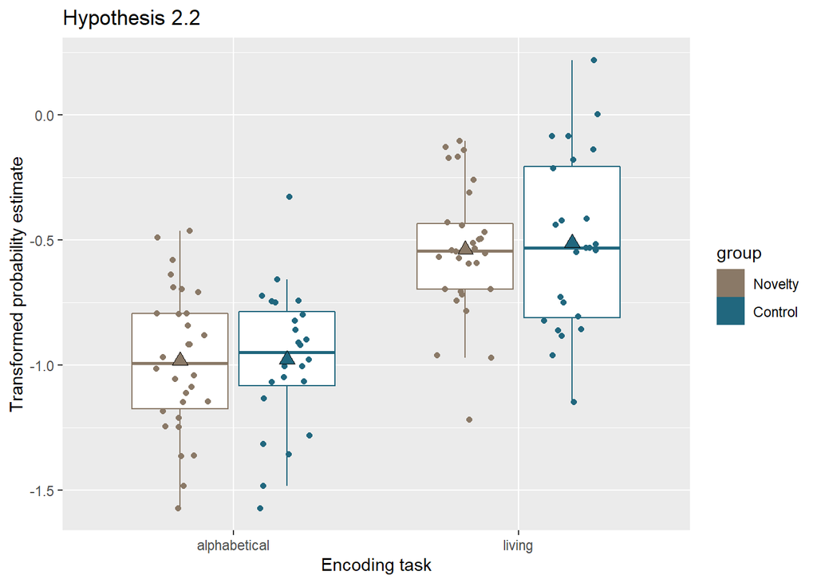

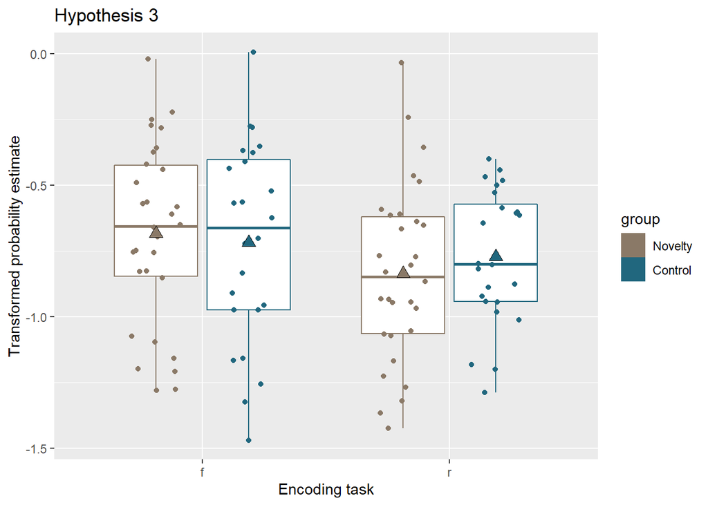

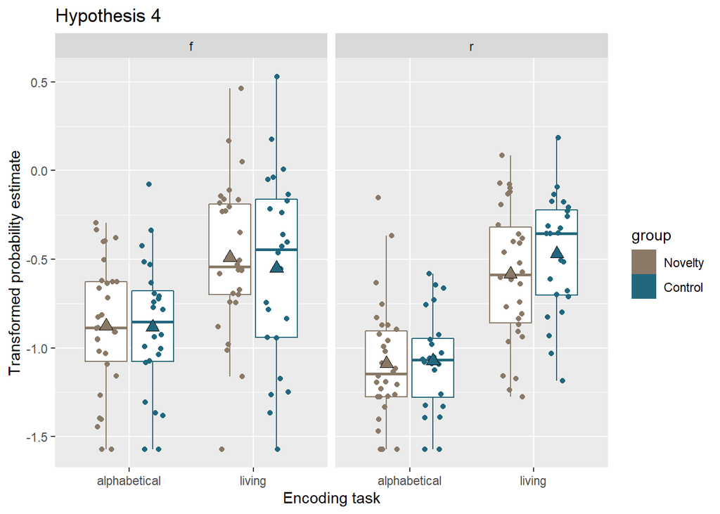

#### Calculate time in hours between starts of encoding and recognition tasks

| subNum | group | condition | recogTime | encodTime | diff |
| --- | --- | --- | --- | --- | --- |
| 2 | 2 | 0 | 2020-2-5 21:43 | 2020-02-04 17:48:14 | 27.91278 |
| 4 | 2 | 1 | 2020-2-7 21:55 | 2020-02-06 17:46:56 | 28.13444 |
| 5 | 1 | 2 | 2020-2-5 17:54 | 2020-02-04 16:38:40 | 25.25556 |
| 6 | 2 | 2 | 2020-2-12 16:29 | 2020-02-11 16:30:18 | 23.97833 |
| 8 | 2 | 3 | 2020-2-12 17:33 | 2020-02-11 19:14:12 | 22.31333 |
| 9 | 1 | 4 | 2020-2-15 21:3 | 2020-02-14 16:41:10 | 28.36389 |
| 10 | 2 | 4 | 2020-2-19 20:19 | 2020-02-18 17:59:28 | 26.32556 |
| 11 | 1 | 5 | 2020-2-15 20:26 | 2020-02-14 17:55:06 | 26.51500 |
| 12 | 2 | 5 | 2020-2-19 18:29 | 2020-02-18 16:48:52 | 25.66889 |
| 13 | 1 | 6 | 2020-2-20 20:36 | 2020-02-19 17:59:00 | 26.61667 |
| 14 | 2 | 6 | 2020-2-20 12:4 | 2020-02-19 16:35:28 | 19.47556 |
| 15 | 1 | 7 | 2020-2-20 20:4 | 2020-02-19 19:05:57 | 24.96750 |
| 16 | 2 | 7 | 2020-3-14 22:27 | 2020-03-13 16:35:24 | 29.86000 |
| 17 | 1 | 8 | 2020-2-29 18:3 | 2020-02-28 19:00:08 | 23.04778 |
| 18 | 2 | 8 | 2020-3-6 18:45 | 2020-03-05 17:40:54 | 25.06833 |
| 19 | 1 | 9 | 2020-3-3 15:37 | 2020-03-02 16:32:55 | 23.06806 |
| 20 | 2 | 9 | 2020-3-7 16:8 | 2020-03-06 16:36:08 | 23.53111 |
| 21 | 1 | 10 | 2020-3-3 20:18 | 2020-03-02 19:11:58 | 25.10056 |
| 22 | 2 | 10 | 2021-3-11 15:22 | 2021-03-10 09:35:46 | 29.77056 |
| 23 | 1 | 11 | 2020-3-5 20:20 | 2020-03-04 18:56:08 | 25.39778 |
| 24 | 2 | 11 | 2021-3-11 16:33 | 2021-03-10 14:20:45 | 26.20417 |
| 25 | 1 | 0 | 2020-3-7 22:42 | 2020-03-06 18:56:52 | 27.75222 |
| 26 | 2 | 0 | 2021-4-14 14:23 | 2021-04-13 10:00:40 | 28.37222 |
| 27 | 1 | 1 | 2020-3-12 19:0 | 2020-03-11 17:41:39 | 25.30583 |
| 28 | 2 | 1 | 2021-4-14 13:9 | 2021-04-13 11:58:23 | 25.17694 |
| 29 | 1 | 2 | 2020-3-12 21:38 | 2020-03-11 18:54:37 | 26.72306 |
| 31 | 1 | 3 | 2020-3-14 0:42 | 2020-03-12 17:44:43 | 30.95472 |
| 33 | 1 | 4 | 2020-3-14 18:27 | 2020-03-13 17:42:49 | 24.73639 |
| 34 | 2 | 4 | 2021-4-16 14:21 | 2021-04-15 15:00:43 | 23.33806 |
| 35 | 1 | 5 | 2020-3-17 18:28 | 2020-03-16 16:33:38 | 25.90611 |
| 36 | 2 | 5 | 2021-4-21 11:14 | 2021-04-20 11:31:15 | 23.71250 |
| 38 | 2 | 6 | 2021-4-22 12:7 | 2021-04-21 09:13:27 | 26.89250 |
| 39 | 1 | 7 | 2020-10-24 13:8 | 2020-10-23 14:01:13 | 23.11306 |
| 40 | 2 | 7 | 2021-4-22 13:23 | 2021-04-21 13:33:32 | 23.82444 |
| 41 | 1 | 8 | 2020-10-27 14:34 | 2020-10-26 12:04:07 | 26.49806 |
| 42 | 2 | 8 | 2021-4-29 14:7 | 2021-04-28 12:59:54 | 25.11833 |
| 43 | 1 | 9 | 2020-10-28 18:29 | 2020-10-27 14:05:59 | 28.38361 |
| 44 | 2 | 9 | 2021-5-5 18:44 | 2021-05-04 18:52:26 | 23.85944 |
| 45 | 1 | 10 | 2021-3-12 18:36 | 2021-03-11 17:04:16 | 25.52889 |
| 46 | 2 | 10 | 2021-5-7 10:57 | NA | NA |
| 47 | 1 | 11 | 2021-3-18 13:4 | 2021-03-17 11:31:56 | 25.53444 |
| 48 | 2 | 11 | 2021-5-8 12:46 | NA | NA |
| 49 | 1 | 0 | 2021-4-13 13:41 | 2021-04-12 14:01:59 | 23.65028 |
| 50 | 2 | 0 | 2021-5-8 9:6 | NA | NA |
| 51 | 1 | 1 | 2021-4-22 21:11 | 2021-04-21 15:37:06 | 29.56500 |
| 53 | 1 | 2 | 2021-4-27 17:5 | 2021-04-26 17:06:48 | 23.97000 |
| 55 | 1 | 3 | 2021-4-29 12:30 | 2021-04-28 09:07:58 | 27.36722 |
| 57 | 1 | 4 | 2021-4-30 16:51 | 2021-04-29 15:06:54 | 25.73500 |
| 59 | 1 | 5 | 2021-4-30 21:5 | 2021-04-29 17:37:17 | 27.46194 |
| 61 | 1 | 6 | 2021-5-6 14:2 | 2021-05-05 12:56:31 | 25.09139 |
| 63 | 1 | 7 | 2021-5-8 13:34 | NA | NA |
| 73 | 1 | 1 | 2020-2-4 12:31 | 2020-02-03 18:54:27 | 17.60917 |
| 74 | 2 | 2 | 2020-10-28 15:52 | 2020-10-27 16:23:20 | 23.47778 |
| 75 | 1 | 10 | 2021-3-9 13:57 | 2021-03-08 11:52:10 | 26.08056 |

### Recall data

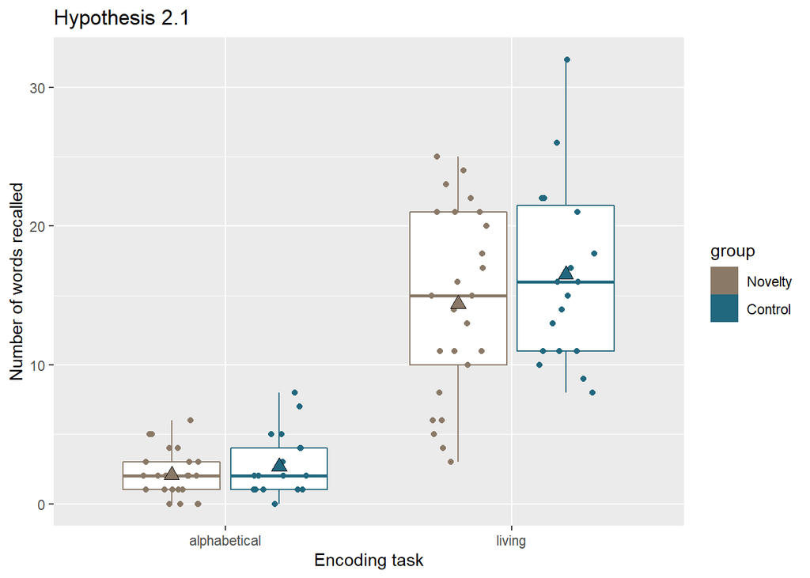

### Hypothesis summary

| Hypothesis | BF10 | BF01 |
| --- | --- | --- |
| 1.1 | 0.1551917 | 6.443643 |
| 1.2 | 0.2359537 | 4.238120 |
| 2.1 | 0.6100023 | 1.639338 |
| 2.2 | 0.3416637 | 2.926854 |
| 3 | 0.3619750 | 2.762622 |
| 4 | 0.5156931 | 1.939138 |

| Group | Number | Percent |
| --- | --- | --- |
| 1 | 30 | 0.8333333 |
| 2 | 24 | 0.6666667 |

| Condition | Novelty group | Control group |
| --- | --- | --- |
| 0 | 2 | 3 |
| 1 | 3 | 2 |
| 2 | 3 | 2 |
| 3 | 2 | 1 |
| 4 | 3 | 2 |
| 5 | 3 | 2 |
| 6 | 2 | 2 |
| 7 | 3 | 2 |
| 8 | 2 | 2 |
| 9 | 2 | 2 |
| 10 | 3 | 2 |
| 11 | 2 | 2 |

As a sanity check, we replicated the level of processing effect with better performance for the living condition (BF10 = 4.122569910^{12}).

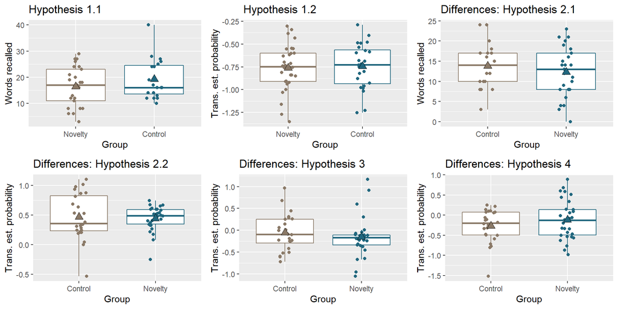

# Is the counterbalancing the same across the tasks?

For instance, are the words were learned in the alphabetical task also labelled as learned as such in the encoding task?

```
## [1] NA
```

```
## [1] NA
```

As long both check return false, there is no problem with the scoring with the recognition data.

### Questionnaire

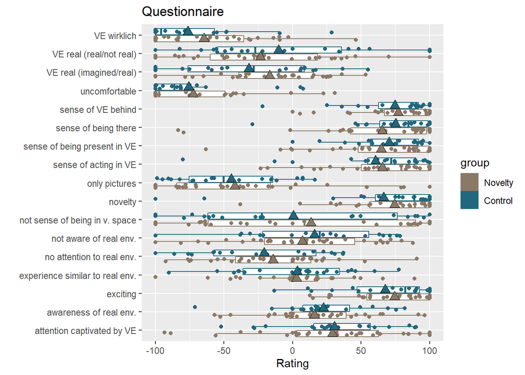